# PA1_template

Amir Farokh

23/12/2021

#### This is the week-2 course project for the ‘Reproducible Research’ course. In this assignment I have presented all the necessary codes that are productive towrad the requeted result in the assignment.

#### 1. The first step is reading the .csv file for setting up the dataset:

```r
knitr::opts_chunk$set(echo = TRUE)
#download.file('https://d396qusza40orc.cloudfront.net/repdata%2Fdata%2Factivity.zip', destfile = './f1')
#unzip('./f1')
cc1 <- read.csv('./activity.csv')
#save(cc1, file = 'cc1.rda')
#load('cc1.rda')
```

##### Eliminating the missing (or NA) values in the dataset

```r
ccn <- complete.cases(cc1)
cc2 <- cc1[ccn,]
```

#### 2. Histogram of the total number of steps taken each day

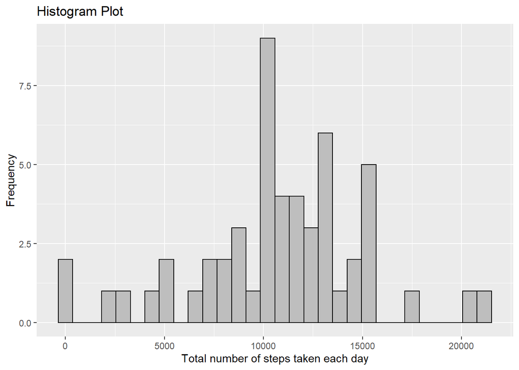

```r
knitr::opts_chunk$set(echo = TRUE)
cd1 <- as.Date(cc2$date, '%Y-%m-%d', tz = 'EST')
cc2$date <- cd1
ce1 <- table(cc2$date)
t1 <- dim(ce1)
td1 <- rep(0, t1)
td2 <- rep(cc2$date[1], t1)
td3 <- td1
td4 <- td1
c1 <- 1
for (i in 1:t1) {
        td1[i] <- sum(cc2$steps[c1:(c1+287)])
        td2[i] <- cc2$date[c1]
        td3[i] <- mean(cc2$steps[c1:(c1+287)])
        #td4[i] <- median(cc2$steps[c1:(c1+287)])
        c1 <- c1+288
}
ac1 <- data.frame(Date = td2, Sum = td1, Mean = td3)
library('ggplot2')
# Plotting the histogram of total number of steps taken each day
g1 <- ggplot(ac1, aes(Sum))
g2 <- g1 + geom_histogram(color = 'black', fill = 'grey')
g3 <- g2 + labs(title="Histogram Plot",x="Total number of steps taken each day", y = "Frequency")
print(g3)
```

#### 3. Mean and median number of steps taken each day

```r
knitr::opts_chunk$set(echo = TRUE)
sprintf('The mean of total steps taken each day during the whole two-month period is: %.2f', mean(ac1$Sum))
```

```
## [1] "The mean of total steps taken each day during the whole two-month period is: 10766.19"
```

```r
sprintf('The median of number of steps taken each day during the whole two-month period is: %.2f', median(ac1$Sum))
```

```
## [1] "The median of number of steps taken each day during the whole two-month period is: 10765.00"
```

##### The mean of total steps taken each day during the whole two-month period is 10766.19

##### The median of number of steps taken each day during the whole two-month period is: 10765.00

#### 4. Time series plot of the average number of steps taken each day

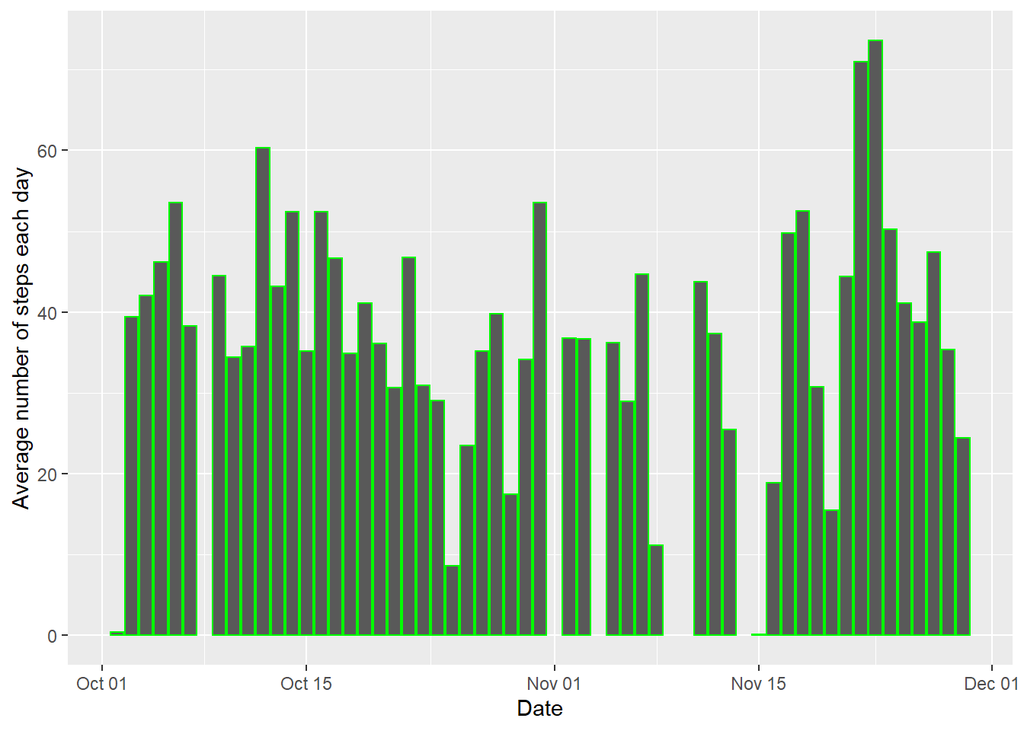

```r
knitr::opts_chunk$set(echo = TRUE)
# This is the plot of average number of steps taken each day (y-axis) and the corresponding dates (x-axis)
ggplot(ac1, aes(x = td2, y = td3)) + geom_col(col = 'green') + xlab('Date') + ylab('Average number of steps each day')
```

#### 5. The 5-minute interval that, on average, contains the maximum number of steps

```r
knitr::opts_chunk$set(echo = TRUE)
cc3 <- order(cc2$interval)
cc4 <- cc2[cc3,]
row.names(cc4) <- 1:dim(cc2)[1]
tm1 <- rep(0, 288)
cf1 <- 1
t2 <- dim.data.frame(td2)[2]
for (i in 1:288) {
        tm1[i] <- mean(cc4$steps[cf1:cf1+t2-1])
        cf1 <- cf1+t2
}
```

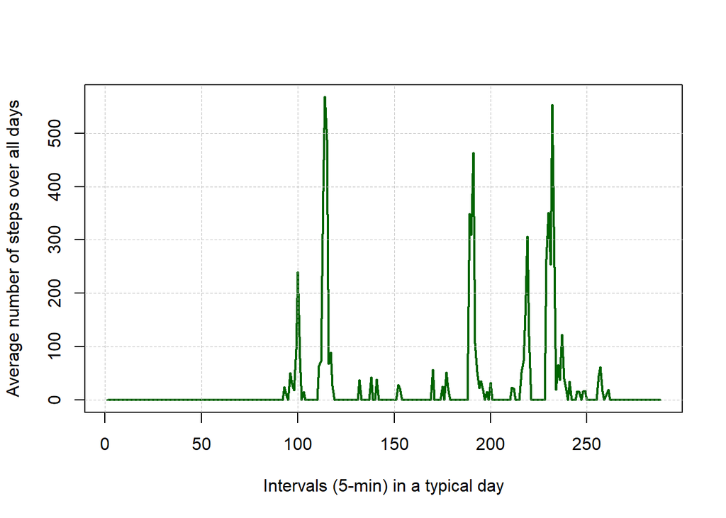

```r
knitr::opts_chunk$set(echo = TRUE)
plot(1:288, tm1, type = 'l', lwd = 2, col='dark green', xlab = 'Intervals (5-min) in a typical day', ylab = 'Average number of steps over all days')
grid(nx=NULL, ny=NULL, lty=2, lwd=0.5, col='gray')
```

```r
cd4 <- which(tm1 == max(tm1))
sprintf('The interval that has the maxium number of steps (on average over the days) is: %d', cd4)
```

```
## [1] "The interval that has the maxium number of steps (on average over the days) is: 114"
```

#### 6. Code to describe and show a strategy for imputing missing data

```r
knitr::opts_chunk$set(echo = TRUE)
te1 <- dim(cc1)[1] - dim(cc2)[1]
sprintf('The total number of missing intervals (NA) is %d, which is equivalent to %d complete days', te1, te1/288)
```

```
## [1] "The total number of missing intervals (NA) is 2304, which is equivalent to 8 complete days"
```

##### The total number of missing intervals (NA) is 2304, which is equivalent to 8 complete days

##### We now mutate the original dataset and fill the NA values with the average data of the two days just after the missing day, then we complete the data sets with having 61 days over the two complete months

```r
knitr::opts_chunk$set(echo = TRUE)
cm1 <- cc1
cm1$date <- as.Date(cm1$date, '%Y-%m-%d', tz = 'EST')
cc6 <- order(cm1$interval)
cm2 <- cm1[cc6,]
row.names(cm2) <- 1:dim(cm2)[1]
ce3 <- dim(cm2[cm2$interval == 0,])[1]
cf2 <- 1
for (i in 1:ce3) {
        for (j in 1:288) {
                if (is.na(cm2$steps[cf2] == T)) {
                        if (is.na(cm2$steps[cf2+1]) == F & is.na(cm2$steps[cf2+2]) == F) {
                                cm2$steps[cf2] <- mean(c(cm2$steps[cf2+1], cm2$steps[cf2+2]))
                        }
                        else {
                                cm2$steps[cf2] <- mean(c(cm2$steps[cf2+3], cm2$steps[cf2+4]))
                        }
                }
                cf2 <- cf2+1
        }
}
cm2$steps[ce3*288] <- 0
cm3 <- cm2[order(cm2$date),]
cm3 <- data.frame(Date = cm3$date, Interval = cm3$interval, Steps = cm3$steps)
```

##### The new datasets with the imputed missing data is achieved and it is named cm3

#### 7. Histogram of the total number of steps taken each day after missing values are imputed

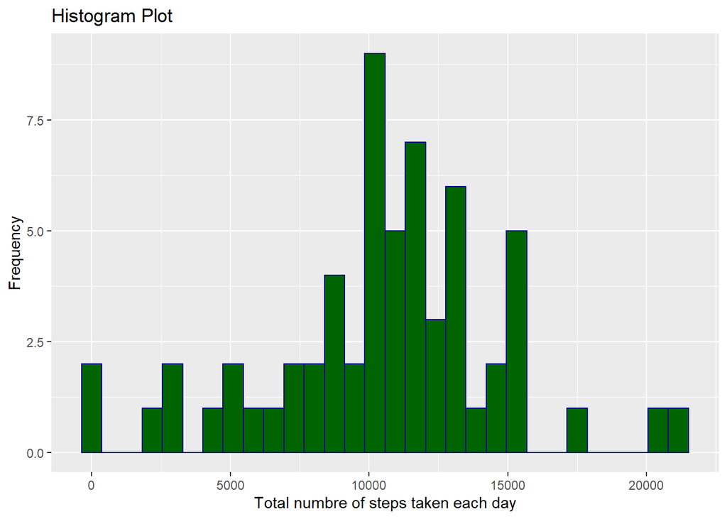

```r
knitr::opts_chunk$set(echo = TRUE)
ce3 <- table(cm3$Date)
t3 <- dim(ce3)
td4 <- rep(0, t3)
td5 <- td4
c5 <- 1
for (i in 1:t3) {
        td4[i] <- as.Date(cm3$Date[c5])
        td5[i] <- sum(cm3$Steps[c5:(c5+287)])
        c5 <- c5+288
}
ac3 <- data.frame(Date = as.POSIXct.Date(td4, '%Y-%m-%d'), Sum = td5)
# # Plotting the histogram of total number of steps taken each day
g1 <- ggplot(ac3, aes(Sum))
g2 <- g1 + geom_histogram(color = 'dark blue', fill = 'dark green')
g3 <- g2 + labs(title="Histogram Plot",x="Total numbre of steps taken each day", y = "Frequency")
print(g3)
```

```r
sprintf('The mean of total steps taken each day during the whole two-month period is: %.2f', mean(ac3$Sum))
```

```
## [1] "The mean of total steps taken each day during the whole two-month period is: 10538.74"
```

```r
sprintf('The median of number of steps taken each day during the whole two-month period is: %.2f', median(ac3$Sum))
```

```
## [1] "The median of number of steps taken each day during the whole two-month period is: 10600.00"
```

##### The mean of total steps taken each day during the whole two-month period is: 10538.74

##### The median of number of steps taken each day during the whole two-month period is: 10600.00

##### Comment: The mean and median numbers have decreased after imputing the missing data. It is clear mathematically that after filling missig data, the number of days increases from 53 to 61, so with having similar values of summation (number of steps), the denominator (number of days) increases. So the mean and median numbers decrease.

#### 8. Panel plot comparing the average number of steps taken per 5-minute interval across weekdays and weekends

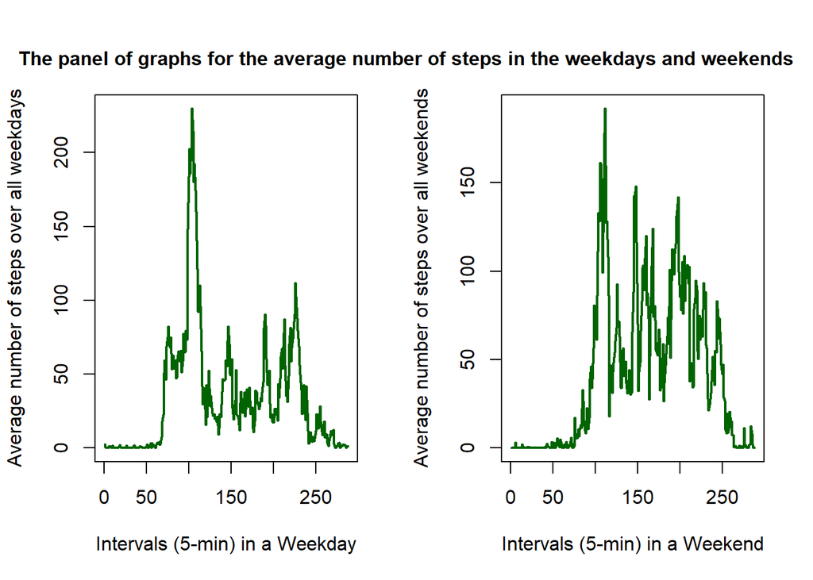

```r
knitr::opts_chunk$set(echo = TRUE)
tw1 <- weekdays(ac3$Date)
tw2 <- rep(0, t3)
tw2[seq(6,t3,7)] <- 1
tw2[seq(7,t3,7)] <- 1
tw3 <- factor(tw2, labels = c('Weekday', 'Weekend'))
cc7 <- order(cm3$Interval)
cc8 <- cm3[cc7,]
tw4 <- rep(tw3, 288)
cc8 <- cbind(cc8, WDE=tw4)
cc9 <- subset(cc8, WDE == 'Weekday')
cc10 <- subset(cc8, WDE == 'Weekend')
s1 <- dim(cc9)[1]/288
s2 <- t3-s1
Interval2 <- rep(0, 288)
Mean2 <- Interval2
Interval3 <- Interval2
Mean3 <- Interval2
c6 <- 1
c7 <- 1
for (i in 1:288) {
        Interval2[i] <- cc9$Interval[c6]
        Mean2[i] <- mean(cc9$Steps[c6:(c6+s1-1)])
        c6 <- c6+s1
        Interval3[i] <- cc10$Interval[c7]
        Mean3[i] <- mean(cc10$Steps[c7:(c7+s2-1)])
        c7 <- c7+s2
}
ac4 <- data.frame(Interval2, Mean2)
ac5 <- data.frame(Interval3, Mean3)
#print(ac4)
#print(ac5)
par(mfrow=c(1,2))
plot(1:288, ac4$Mean2, type = 'l', lwd = 2, col='dark green', xlab = 'Intervals (5-min) in a Weekday', ylab = 'Average number of steps over all weekdays')
plot(1:288, ac5$Mean3, type = 'l', lwd = 2, col='dark green', xlab = 'Intervals (5-min) in a Weekend', ylab = 'Average number of steps over all weekends')
mtext('The panel of graphs for the average number of steps in the weekdays and weekends', side = 3, line = -3, outer = TRUE, cex = 1, font = 2)
```